# Part A

## 1) Please refer the table below to answer below questions:

| Planned to Purchase Product A | Actually placed order for Product A - Yes | Actually placed order for Product A - No | Total |
| --- | --- | --- | --- |
| Yes | 400 | 100 | 500 |
| No | 200 | 1300 | 1500 |
| Total | 600 | 1400 | 2000 |

### 1.A.) Refer above table and find the joint probability of the people who planned to purchase and actually placed an order

(People who planned to Purchase Product A) AND (People who actually placed an order for Product A) = 400 = m

Total People = 2000 = n

Joint Probability = m/n

```python
m = 400 #(People who planned to Purchase Product A) AND (People who actually placed an order for Product A)
n = 2000 #Total People
JointProbability = m/n

print("Joint probability of the people who planned to purchase and actually placed an order = ",JointProbability)
```

```
Joint probability of the people who planned to purchase and actually placed an order =  0.2
```

### 1.B.) Refer to the above table and find the joint probability of the people who planned to purchase and actually placed an order, given that people planned to purchase

It is given that people planned to purchase

People who planned to purchase and actually placed an order = 400 = m

Thus, the population of total people becomes = 500 = n

```python
m = 400 #People who planned to purchase and actually placed an order
n = 500 #Given that people planned to purchase, Total People
JointProbability = m/n

print("Joint probability of the people who planned to purchase and actually placed an order, given that people planned to purchase = ",JointProbability)
```

```
Joint probability of the people who planned to purchase and actually placed an order, given that people planned to purchase =  0.8
```

## 2) An electrical manufacturing company conducts quality checks at specified periods on the products it manufactures. Historically, the failure rate for the manufactured item is 5%. Suppose a random sample of 10 manufactured items is selected. Answer the following questions.

This question is modelled in the form of a Binomial Distribution.

Why? The question talks about discrete random variable in the form of number of defective products. From the given sample, each product can be either OK or DEFECTIVE. In Binomial Distribution terminology, it is equivalent to saying SUCCESS or FAILURE.

Let's import the libraries required to solve this and subsequent problems on Probability Distributions.

```python
import numpy as np #For Array Operations
import scipy.stats as stats #For Various Probability Distribution Calculations
import matplotlib.pyplot as plt #For Plotting
print("Libraries: Numpy, Scipy.Stas & Matplotlib imported successfully")
```

```
Libraries: Numpy, Scipy.Stas & Matplotlib imported successfully
```

```python
p   =  0.05 # failure rate for manufactured items is 5%
n   =  10 # sample size
k   =  np.arange(0,11) # An array of random variables representing number of defectives OR P(X=k)
print('Failure rate for manufactured items:p =',p,"\nSample size:n =",n,"\nArray of Samples:k =",k)
```

```
Failure rate for manufactured items:p = 0.05
Sample size:n = 10
Array of Samples:k = [ 0  1  2  3  4  5  6  7  8  9 10]
```

```python
binomial = stats.binom.pmf(k,n,p) #P(X=0,1,2...,10)
print(binomial)
```

```
[5.98736939e-01 3.15124705e-01 7.46347985e-02 1.04750594e-02
 9.64808106e-04 6.09352488e-05 2.67259863e-06 8.03789063e-08
 1.58642578e-09 1.85546875e-11 9.76562500e-14]
```

### 2.A.) Probability that none of the items are defective?

```python
#P(X=0)
print('Probability that none of the items are defective is %1.4f' %binomial[0])
```

```
Probability that none of the items are defective is 0.5987
```

### 2.B.) Probability that exactly one of the items is defective?

```python
#P(X=1)
print('Probability that exactly one of the items is defective is %1.4f' %binomial[1])
```

```
Probability that exactly one of the items is defective is 0.3151
```

### 2.C.) Probability that two or fewer of the items are defective?

To find the answer for this question, we need to calculate cumulative probability of upto 2 defective items

```python
cumbinomial = stats.binom.cdf(k,n,p)#Cumulative Probabilities of Binomial Distribution OR P(X<=2)
print(cumbinomial)
print("")
print('Probability that two or fewer of the items are defective is %1.4f' %cumbinomial[2])
```

```
[0.59873694 0.91386164 0.98849644 0.9989715  0.99993631 0.99999725
 0.99999992 1.         1.         1.         1.        ]

Probability that two or fewer of the items are defective is 0.9885
```

### 2.D.) Probability that three or more of the items are defective ?

```python
P = 1- cumbinomial[2]#Removing the cumulative probability of two or fewer items defective OR P(X>=3)
print('Probability that three or more of the items are defective is %1.4f' % P)
```

```
Probability that three or more of the items are defective is 0.0115
```

## 3) A car salesman sells on an average 3 cars per week.

This is a typical Poisson Distribution problem as the rate is given and probabilities are expected to be calculated.

```python
rate =  3 #Cars sold per week
n    =  np.arange(0,20) #Array of Random Variables OR P(X=n)
#20 is randomly chosen until the probability converges to 1
cumpoisson = stats.poisson.cdf(n,rate) #Cumulative Poisson Distribution Probabilities
print(cumpoisson)
```

```
[0.04978707 0.19914827 0.42319008 0.64723189 0.81526324 0.91608206
 0.96649146 0.9880955  0.99619701 0.99889751 0.99970766 0.99992861
 0.99998385 0.9999966  0.99999933 0.99999988 0.99999998 1.
 1.         1.        ]
```

### 3.A.) What is Probability that in a given week he will sell some cars?

```python
P   = 1 - cumpoisson[0]#P = probability that the salesman sells some cars
print('Probability that in a given week the salesman will sell some cars is %1.4f' % P)
```

```
Probability that in a given week the salesman will sell some cars is 0.9502
```

### 3.B.) What is Probability that in a given week he will sell 2 or more but less than 5 cars?

```python
# Let P1 be the probability that the salesman sells more than 4 cars
P1 = cumpoisson[4] # P(X >=4)
# Let P2 be the probability that the salesman sells more than 1 car
P2 = cumpoisson[1] # P(X >=1)
P = P1 - P2 # Probability that the salesman will sell between 2 and 5 cars OR P(2<=X<5)
print('Probability that in a given week the salesman will sell 2 or more but less than 5 cars is %1.4f' % P)
```

```
Probability that in a given week the salesman will sell 2 or more but less than 5 cars is 0.6161
```

### 3.C.) Plot the poisson distribution function for cumulative probability of cars sold per-week vs number of cars sold per week.

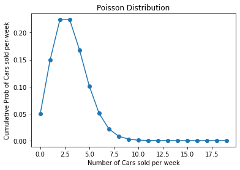

```python
poisson = stats.poisson.pmf(n,rate)
plt.plot(n,poisson, 'o-')
plt.title('Poisson Distribution')
plt.xlabel('Number of Cars sold per week')
plt.ylabel('Cumulative Prob of Cars sold per-week')
plt.show()
```

## 4) Accuracy in understanding orders for a speech based bot at a restaurant is important for the Company X which has designed, marketed and launched the product for a contactless delivery due to the COVID-19 pandemic. Recognition accuracy that measures the percentage of orders that are taken correctly is 86.8%. Suppose that you place an order with the bot and two friends of yours independently place orders with the same bot. Answer the following questions.

This is also a problem in Binomial Distribution where the sample size is 3 and SUCCESS is percentage of orders that are taken correctly, which is 86.8%

```python
p1   =  0.868 # Recognition Accuracy
n1   =  3 # sample size
k1   =  np.arange(0,4) # An array of random variables OR P(X=k)
print('Recognition:p =',p1,"\nSample size:n =",n1,"\nArray of Samples:k =",k1)
```

```
Recognition:p = 0.868
Sample size:n = 3
Array of Samples:k = [0 1 2 3]
```

```python
binomial = stats.binom.pmf(k1,n1,p1) #P(X=0,1,2,3)
print(binomial)
```

```
[0.00229997 0.0453721  0.2983559  0.65397203]
```

### 4.A. What is the probability that all three orders will be recognised correctly?

```python
#P(X=3)
print('Probability that all three orders will be recognised correctly is %1.4f' %binomial[3])
```

```
Probability that all three orders will be recognised correctly is 0.6540
```

### 4.B. What is the probability that none of the three orders will be recognised correctly?

```python
#P(X=0)
print('Probability that none of the three orders will be recognised correctly is %1.4f' %binomial[0])
```

```
Probability that none of the three orders will be recognised correctly is 0.0023
```

### 4.C. What is the probability that at least two of the three orders will be recognised correctly?

```python
#P(X>=2) = P(X=2) + P(X=3)
P_2 = binomial[2]
P_3 = binomial[3]
print("Probability that at least two of the three orders will be recognised correctly is ", round(P_2+P_3,4))
```

```
Probability that at least two of the three orders will be recognised correctly is  0.9523
```

## 5) Explain 1 real life industry scenario (other than the ones mentioned above) where you can use the concepts learnt in this module of Applied Statistics to get data driven business solution.

**Automobile Industry**

The number of vehicles produced per shift by a mass vehicle manufacturer is very important, like Maruti or Hero MotoCorp as they have huge sale volumes. The probability to meet production targets during lean and crunch (festive) months helps companies in planning their supply chain and labour requirements. In this case Poisson distribution can be used. Companies have production targets to be met in order to satisfy the customer demand. The targets can be broken down to per shift basis. The company is required to produce a certain number of vehicles per shift to meet the stipulated targets. The distribution can help understand weekly, monthly, seasonal discrepancies and forecast production optimally. The kind of management questions that can be answered through this are:

1) What is the probability to produce 'x' cars in a shift given the rate of production per shift is 'y'? 2) What is the probability to produce cars between 'x' and 'y' in a shift, given the rate of production per shift is 'z'?

# Part B

### DOMAIN:

Sports

### CONTEXT:

Company X manages the men's top professional basketball division of the American league system. The dataset contains information on all the teams that have participated in all the past tournaments. It has data about how many baskets each team scored, conceded, how many times they came within the first 2 positions, how many tournaments they have qualified, their best position in the past, etc.

### DATA DESCRIPTION:

Basketball.csv - The data set contains information on all the teams so far participated in all the past tournaments.

### DATA DICTIONARY:

1. Team: Team’s name
2. Tournament: Number of played tournaments.
3. Score: Team’s score so far.
4. PlayedGames: Games played by the team so far.
5. WonGames: Games won by the team so far.
6. DrawnGames: Games drawn by the team so far.
7. LostGames: Games lost by the team so far.
8. BasketScored: Basket scored by the team so far.
9. BasketGiven: Basket scored against the team so far.
10. TournamentChampion: How many times the team was a champion of the tournaments so far.
11. Runner-up: How many times the team was a runners-up of the tournaments so far.
12. TeamLaunch: Year the team was launched on professional basketball.
13. HighestPositionHeld: Highest position held by the team amongst all the tournaments played.

### PROJECT OBJECTIVE:

Company’s management wants to invest on proposals on managing some of the best teams in the league. The analytics department has been assigned with a task of creating a report on the performance shown by the teams. Some of the older teams are already in contract with competitors. Hence Company X wants to understand which teams they can approach which will be a deal win for them.

## 1.) Read the data set, clean the data and prepare final dataset to be used for analysis.

### Import Python Libraries

```python
import pandas as pd
import numpy as np
import matplotlib.pyplot as plt
%matplotlib inline
import seaborn as sns
print('Libraries imported successfully')
```

```
Libraries imported successfully
```

### Read the data set

```python
df1 = pd.read_csv("DS - Part2 - Basketball.csv") # Load the dataset in Pandas dataframe
df1.head() # Display first 5 rows
```

|  | Team | Tournament | Score | PlayedGames | WonGames | DrawnGames | LostGames | BasketScored | BasketGiven | TournamentChampion | Runner-up | TeamLaunch | HighestPositionHeld |
| --- | --- | --- | --- | --- | --- | --- | --- | --- | --- | --- | --- | --- | --- |
| 0 | Team 1 | 86 | 4385 | 2762 | 1647 | 552 | 563 | 5947 | 3140 | 33 | 23 | 1929 | 1 |
| 1 | Team 2 | 86 | 4262 | 2762 | 1581 | 573 | 608 | 5900 | 3114 | 25 | 25 | 1929 | 1 |
| 2 | Team 3 | 80 | 3442 | 2614 | 1241 | 598 | 775 | 4534 | 3309 | 10 | 8 | 1929 | 1 |
| 3 | Team 4 | 82 | 3386 | 2664 | 1187 | 616 | 861 | 4398 | 3469 | 6 | 6 | 1931to32 | 1 |
| 4 | Team 5 | 86 | 3368 | 2762 | 1209 | 633 | 920 | 4631 | 3700 | 8 | 7 | 1929 | 1 |

From the first 5 rows of the dataset, the table looks OK. However, this does not give us any indication of the datatypes. Also one value in TeamLaunch column in 1931to32 which can create problem in EDA. This column needs to be checked and rectified as required.

### Clean the data

```python
df1.shape # Check the size of the tabular data
```

```
(61, 13)
```

There are 61 rows and 13 columns in the dataframe basketball.

```python
df1.info() # Check basic information about the dataframe
```

```
<class 'pandas.core.frame.DataFrame'>
RangeIndex: 61 entries, 0 to 60
Data columns (total 13 columns):
 #   Column               Non-Null Count  Dtype
---  ------               --------------  -----
 0   Team                 61 non-null     object
 1   Tournament           61 non-null     int64
 2   Score                61 non-null     object
 3   PlayedGames          61 non-null     object
 4   WonGames             61 non-null     object
 5   DrawnGames           61 non-null     object
 6   LostGames            61 non-null     object
 7   BasketScored         61 non-null     object
 8   BasketGiven          61 non-null     object
 9   TournamentChampion   61 non-null     object
 10  Runner-up            61 non-null     object
 11  TeamLaunch           61 non-null     object
 12  HighestPositionHeld  61 non-null     int64
dtypes: int64(2), object(11)
memory usage: 6.3+ KB
```

The Team column should be the only column with 'object' data type as it is a categorical variable.

But, only Tournament and HighestPositionHeld columns have 'int64' data type.

```python
df1.describe(include='all') # Check basic statistics of the dataframe
```

|  | Team | Tournament | Score | PlayedGames | WonGames | DrawnGames | LostGames | BasketScored | BasketGiven | TournamentChampion | Runner-up | TeamLaunch | HighestPositionHeld |
| --- | --- | --- | --- | --- | --- | --- | --- | --- | --- | --- | --- | --- | --- |
| count | 61 | 61.000000 | 61 | 61 | 61 | 61 | 61 | 61 | 61 | 61 | 61 | 61 | 61.000000 |
| unique | 61 | NaN | 61 | 53 | 59 | 57 | 56 | 60 | 61 | 8 | 10 | 47 | NaN |
| top | Team 39 | NaN | 553 | 30 | 8 | 95 | 37 | 70 | 252 | - | - | 1929 | NaN |
| freq | 1 | NaN | 1 | 3 | 2 | 2 | 3 | 2 | 1 | 52 | 48 | 10 | NaN |
| mean | NaN | 24.000000 | NaN | NaN | NaN | NaN | NaN | NaN | NaN | NaN | NaN | NaN | 7.081967 |
| std | NaN | 26.827225 | NaN | NaN | NaN | NaN | NaN | NaN | NaN | NaN | NaN | NaN | 5.276663 |
| min | NaN | 1.000000 | NaN | NaN | NaN | NaN | NaN | NaN | NaN | NaN | NaN | NaN | 1.000000 |
| 25% | NaN | 4.000000 | NaN | NaN | NaN | NaN | NaN | NaN | NaN | NaN | NaN | NaN | 3.000000 |
| 50% | NaN | 12.000000 | NaN | NaN | NaN | NaN | NaN | NaN | NaN | NaN | NaN | NaN | 6.000000 |
| 75% | NaN | 38.000000 | NaN | NaN | NaN | NaN | NaN | NaN | NaN | NaN | NaN | NaN | 10.000000 |
| max | NaN | 86.000000 | NaN | NaN | NaN | NaN | NaN | NaN | NaN | NaN | NaN | NaN | 20.000000 |

Statistics for only 2 columns (Tournament & HighestPositionHeld) are being displayed indicating that the other columns are recognized as non-numerical by Pandas. Most of the numerical columns are not populating descriptive statistics and instead showing NaN. TournamentChampion and Runner-up columns have - in top row indicating that some rows in these columns don't have numerical values.

```python
df1.tail() # Display last 5 rows
```

|  | Team | Tournament | Score | PlayedGames | WonGames | DrawnGames | LostGames | BasketScored | BasketGiven | TournamentChampion | Runner-up | TeamLaunch | HighestPositionHeld |
| --- | --- | --- | --- | --- | --- | --- | --- | --- | --- | --- | --- | --- | --- |
| 56 | Team 57 | 1 | 34 | 38 | 8 | 10 | 20 | 38 | 66 | - | - | 2009-10 | 20 |
| 57 | Team 58 | 1 | 22 | 30 | 7 | 8 | 15 | 37 | 57 | - | - | 1956-57 | 16 |
| 58 | Team 59 | 1 | 19 | 30 | 7 | 5 | 18 | 51 | 85 | - | - | 1951~52 | 16 |
| 59 | Team 60 | 1 | 14 | 30 | 5 | 4 | 21 | 34 | 65 | - | - | 1955-56 | 15 |
| 60 | Team 61 | 1 | - | - | - | - | - | - | - | - | - | 2017~18 | 9 |

It is clear from the above table that Team 61 Row, TournamentChampion and Runner-up coulmns have '-' that needs to be replaced. We can assume that the '-' indicates that data is not available at these locations and '-' should be replaced with 0. It would not be prudent to drop the rows and columns containing '-' as they have some valid data points available.

```python
df1=df1.replace('-',0) #Replace '-' with 0
df1.tail()
```

|  | Team | Tournament | Score | PlayedGames | WonGames | DrawnGames | LostGames | BasketScored | BasketGiven | TournamentChampion | Runner-up | TeamLaunch | HighestPositionHeld |
| --- | --- | --- | --- | --- | --- | --- | --- | --- | --- | --- | --- | --- | --- |
| 56 | Team 57 | 1 | 34 | 38 | 8 | 10 | 20 | 38 | 66 | 0 | 0 | 2009-10 | 20 |
| 57 | Team 58 | 1 | 22 | 30 | 7 | 8 | 15 | 37 | 57 | 0 | 0 | 1956-57 | 16 |
| 58 | Team 59 | 1 | 19 | 30 | 7 | 5 | 18 | 51 | 85 | 0 | 0 | 1951~52 | 16 |
| 59 | Team 60 | 1 | 14 | 30 | 5 | 4 | 21 | 34 | 65 | 0 | 0 | 1955-56 | 15 |
| 60 | Team 61 | 1 | 0 | 0 | 0 | 0 | 0 | 0 | 0 | 0 | 0 | 2017~18 | 9 |

The TeamLaunch column contains 'Year the team was launched on professional basketball'. This implies that there can only be one year on which a team was launched. The team cannot be launched over a period of 2 or more years. Hence, to rectify this column we can ignore the second year that appears and consider only the first 4 characters are the year of launch of the team.

```python
df1['TeamLaunch'] = df1['TeamLaunch'].str[:4] #Extract first 4 characters from TeamLaunch column as the year
df1['TeamLaunch']
```

```
0     1929
1     1929
2     1929
3     1931
4     1929
      ...
56    2009
57    1956
58    1951
59    1955
60    2017
Name: TeamLaunch, Length: 61, dtype: object
```

### Prepare Final Dataset for Analysis

```python
basketball = df1.astype("int64", errors='ignore') #Convert datatype to numerical for EDA
basketball.info() #Check info of cleaned data
```

```
<class 'pandas.core.frame.DataFrame'>
RangeIndex: 61 entries, 0 to 60
Data columns (total 13 columns):
 #   Column               Non-Null Count  Dtype
---  ------               --------------  -----
 0   Team                 61 non-null     object
 1   Tournament           61 non-null     int64
 2   Score                61 non-null     int64
 3   PlayedGames          61 non-null     int64
 4   WonGames             61 non-null     int64
 5   DrawnGames           61 non-null     int64
 6   LostGames            61 non-null     int64
 7   BasketScored         61 non-null     int64
 8   BasketGiven          61 non-null     int64
 9   TournamentChampion   61 non-null     int64
 10  Runner-up            61 non-null     int64
 11  TeamLaunch           61 non-null     int64
 12  HighestPositionHeld  61 non-null     int64
dtypes: int64(12), object(1)
memory usage: 6.3+ KB
```

This step has converted the datatype of all numerical columns to integers, since the numeric columns have integer values.

```python
basketball.describe() #Check statistics after correcting the datatypes
```

|  | Tournament | Score | PlayedGames | WonGames | DrawnGames | LostGames | BasketScored | BasketGiven | TournamentChampion | Runner-up | TeamLaunch | HighestPositionHeld |
| --- | --- | --- | --- | --- | --- | --- | --- | --- | --- | --- | --- | --- |
| count | 61.000000 | 61.000000 | 61.000000 | 61.000000 | 61.000000 | 61.000000 | 61.000000 | 61.000000 | 61.000000 | 61.000000 | 61.000000 | 61.000000 |
| mean | 24.000000 | 901.426230 | 796.819672 | 303.967213 | 188.934426 | 303.754098 | 1140.344262 | 1140.229508 | 1.426230 | 1.409836 | 1958.918033 | 7.081967 |
| std | 26.827225 | 1134.899121 | 876.282765 | 406.991030 | 201.799477 | 294.708594 | 1506.740211 | 1163.710766 | 5.472535 | 4.540107 | 27.484114 | 5.276663 |
| min | 1.000000 | 0.000000 | 0.000000 | 0.000000 | 0.000000 | 0.000000 | 0.000000 | 0.000000 | 0.000000 | 0.000000 | 1929.000000 | 1.000000 |
| 25% | 4.000000 | 96.000000 | 114.000000 | 34.000000 | 24.000000 | 62.000000 | 153.000000 | 221.000000 | 0.000000 | 0.000000 | 1935.000000 | 3.000000 |
| 50% | 12.000000 | 375.000000 | 423.000000 | 123.000000 | 95.000000 | 197.000000 | 430.000000 | 632.000000 | 0.000000 | 0.000000 | 1951.000000 | 6.000000 |
| 75% | 38.000000 | 1351.000000 | 1318.000000 | 426.000000 | 330.000000 | 563.000000 | 1642.000000 | 1951.000000 | 0.000000 | 0.000000 | 1978.000000 | 10.000000 |
| max | 86.000000 | 4385.000000 | 2762.000000 | 1647.000000 | 633.000000 | 1070.000000 | 5947.000000 | 3889.000000 | 33.000000 | 25.000000 | 2017.000000 | 20.000000 |

```python
#Let's create few more columns for analysis purpose as the table has only one categorical variable
basketball['IfWinner']=basketball['TournamentChampion']>0 #Has the team ever been a tournament champion?
basketball['BasketDiff']=basketball['BasketScored']-basketball['BasketGiven'] #Basket Difference
basketball['NetScorer']=basketball['BasketDiff']>0 #Is the basket difference of a team positiive? Scored more than conceded?
basketball['Win Percent']=round((basketball['WonGames']/basketball['PlayedGames'])*100,2) #Winning percentage of teams
basketball['Loss Percent']=round((basketball['LostGames']/basketball['PlayedGames'])*100,2) #Loss percentage of teams
basketball['Drawn Percent']=round((basketball['DrawnGames']/basketball['PlayedGames'])*100,2) #Draw percentage of teams
basketball['NetWinner']=(basketball['Win Percent']>basketball['Loss Percent']) & (basketball['Win Percent']> basketball['Drawn Percent'])#Whether the team is a net winner?
basketball.head()
```

|  | Team | Tournament | Score | PlayedGames | WonGames | DrawnGames | LostGames | BasketScored | BasketGiven | TournamentChampion | Runner-up | TeamLaunch | HighestPositionHeld | IfWinner | BasketDiff | NetScorer | Win Percent | Loss Percent | Drawn Percent | NetWinner |
| --- | --- | --- | --- | --- | --- | --- | --- | --- | --- | --- | --- | --- | --- | --- | --- | --- | --- | --- | --- | --- |
| 0 | Team 1 | 86 | 4385 | 2762 | 1647 | 552 | 563 | 5947 | 3140 | 33 | 23 | 1929 | 1 | True | 2807 | True | 59.63 | 20.38 | 19.99 | True |
| 1 | Team 2 | 86 | 4262 | 2762 | 1581 | 573 | 608 | 5900 | 3114 | 25 | 25 | 1929 | 1 | True | 2786 | True | 57.24 | 22.01 | 20.75 | True |
| 2 | Team 3 | 80 | 3442 | 2614 | 1241 | 598 | 775 | 4534 | 3309 | 10 | 8 | 1929 | 1 | True | 1225 | True | 47.48 | 29.65 | 22.88 | True |
| 3 | Team 4 | 82 | 3386 | 2664 | 1187 | 616 | 861 | 4398 | 3469 | 6 | 6 | 1931 | 1 | True | 929 | True | 44.56 | 32.32 | 23.12 | True |
| 4 | Team 5 | 86 | 3368 | 2762 | 1209 | 633 | 920 | 4631 | 3700 | 8 | 7 | 1929 | 1 | True | 931 | True | 43.77 | 33.31 | 22.92 | True |

## 2.) Perform detailed statistical analysis and EDA using univariate, bi-variate and multivariate EDA techniques to get data driven insights on recommending which teams they can approach which will be a deal win for them. Also as a data and statistics expert you have to develop a detailed performance report using this data

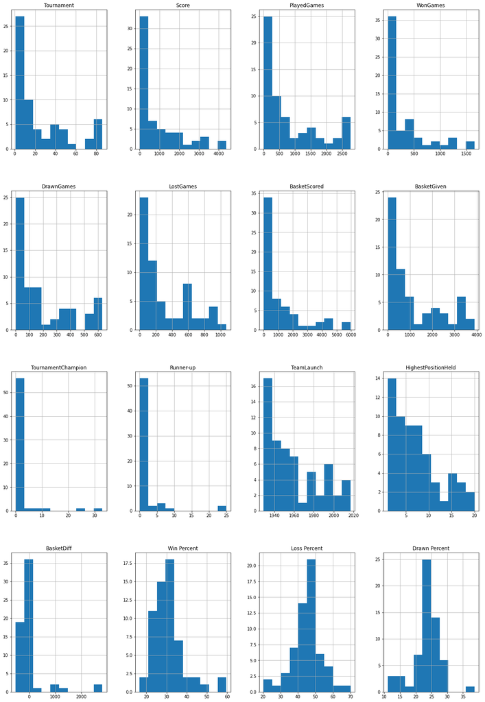

```python
basketball.hist(figsize=(20,30)); #Plot histogram of all numerical variables
```

**Observations** The data looks to be skewed to the right as most of the data is concentrated towards the left end of the histograms.

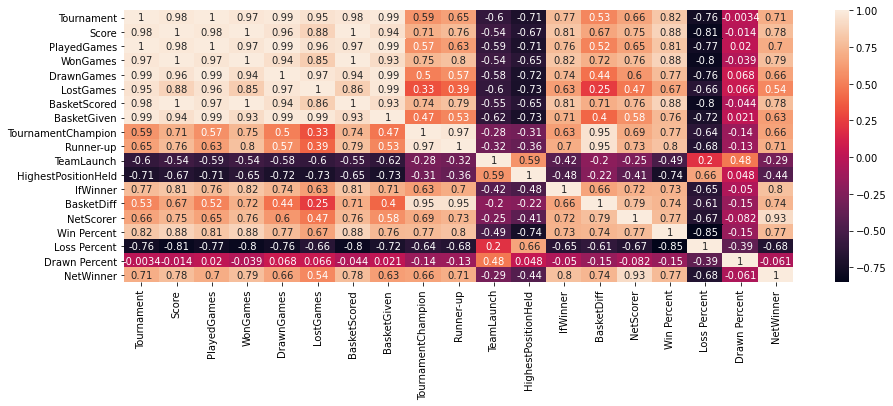

```python
corr_mat=basketball.corr() #Correlation matrix
fig, ax = plt.subplots(figsize=(15,5)) #Set Figure Size
sns.heatmap(corr_mat,annot=True); #Plot heatmap of correlation matrix
```

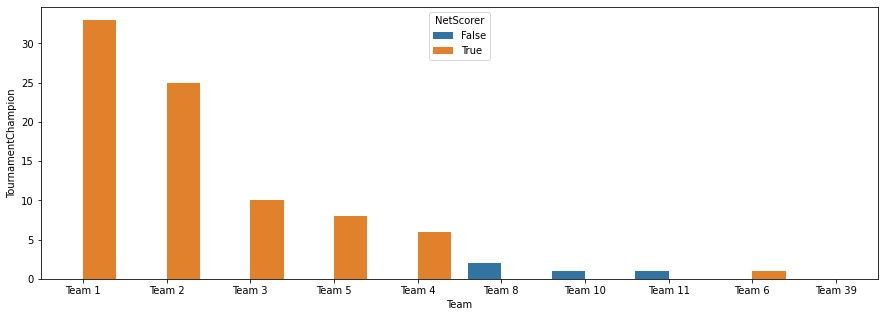

```python
#Which team has won most tournaments?
temp = basketball.sort_values('TournamentChampion',ascending=False).head(10)
fig, ax = plt.subplots(figsize=(15,5)) #Set Figure Size
sns.barplot(x="Team", y = 'TournamentChampion',data=temp,hue='NetScorer');
```

Team 1 has won the most tournaments. Teams 8,10 and 11 have won the tournaments with a negative basket difference. They have conceded more baskets than scored.

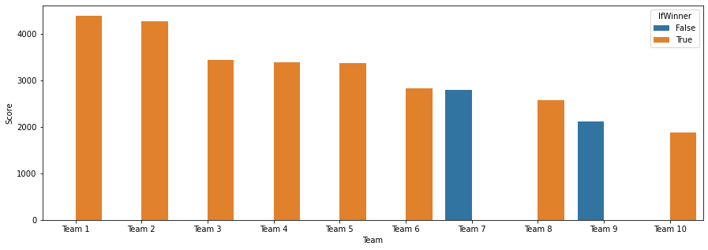

```python
#Which teams have the highest scores?
temp = basketball.sort_values('Score',ascending=False).head(10)
fig, ax = plt.subplots(figsize=(15,5)) #Set Figure Size
sns.barplot(x="Team", y = 'Score',data=temp,hue='IfWinner');
```

Teams 7 and 9 are in the Top 10 scoring teams and yet haven't won the championship even once.

```python
#Which is the oldest team?
basketball.sort_values('TeamLaunch',ascending=True).head(1)
```

|  | Team | Tournament | Score | PlayedGames | WonGames | DrawnGames | LostGames | BasketScored | BasketGiven | TournamentChampion | Runner-up | TeamLaunch | HighestPositionHeld | IfWinner | BasketDiff | NetScorer | Win Percent | Loss Percent | Drawn Percent | NetWinner |
| --- | --- | --- | --- | --- | --- | --- | --- | --- | --- | --- | --- | --- | --- | --- | --- | --- | --- | --- | --- | --- |
| 0 | Team 1 | 86 | 4385 | 2762 | 1647 | 552 | 563 | 5947 | 3140 | 33 | 23 | 1929 | 1 | True | 2807 | True | 59.63 | 20.38 | 19.99 | True |

```python
#Youngest/Newest team
basketball.sort_values('TeamLaunch',ascending=False).head(1)
```

|  | Team | Tournament | Score | PlayedGames | WonGames | DrawnGames | LostGames | BasketScored | BasketGiven | TournamentChampion | Runner-up | TeamLaunch | HighestPositionHeld | IfWinner | BasketDiff | NetScorer | Win Percent | Loss Percent | Drawn Percent | NetWinner |
| --- | --- | --- | --- | --- | --- | --- | --- | --- | --- | --- | --- | --- | --- | --- | --- | --- | --- | --- | --- | --- |
| 60 | Team 61 | 1 | 0 | 0 | 0 | 0 | 0 | 0 | 0 | 0 | 0 | 2017 | 9 | False | 0 | False | NaN | NaN | NaN | False |

Team 61 is the youngest team!

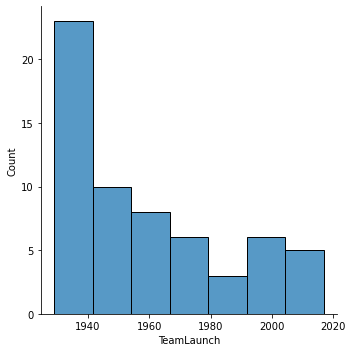

```python
#Team Launch Year distribution
sns.displot(x='TeamLaunch',data=basketball)
```

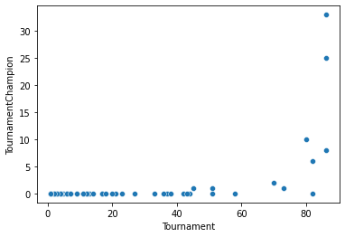

```python
#Is there a relation between number of tournaments played and tournament championships?
sns.scatterplot(data=basketball, x="Tournament", y="TournamentChampion");
```

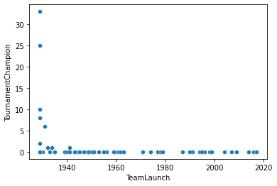

```python
#Is there a relation between team launch year and tournament championships?
sns.scatterplot(data=basketball, x="TeamLaunch", y="TournamentChampion");
```

Older teams (<1940) have won multiple championships. Newer teams haven't fared well with winning championships.

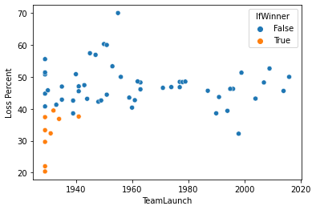

```python
sns.scatterplot(data=basketball, x="TeamLaunch", y="Loss Percent",hue='IfWinner');
```

Winning teams have low loss percent. New teams have very high loss percent.

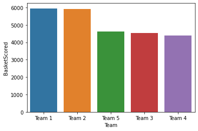

```python
#Team with Highest Goals
b = basketball.sort_values('BasketScored',ascending=False).head()
sns.barplot(x="Team", y = 'BasketScored',data=b);
```

Team 1 has scored maximum baskets. Team 2 has also scored similar number of baskets as Team 1 but less than Team 1.

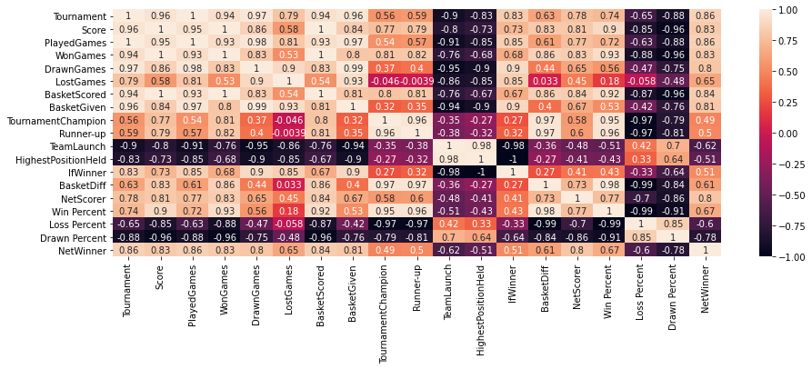

```python
#Recommendations - Which teams to approach for a winning deal
c=basketball.sort_values('TournamentChampion',ascending=False).head(10) #Top 10 tournament champions
corr_mat_c=c.corr() #Correlation matrix
fig, ax = plt.subplots(figsize=(15,5)) #Set Figure Size
sns.heatmap(corr_mat_c,annot=True); #Plot heatmap of correlation matrix
```

Based on above heat map - BasketDiff, Win Percent, Loss Percent, Runner-up and Games Won are highly correlated with Tournament Championships. **NOTE** - Correlation does not indicate causation. These are not the only factors leading to championships. But they are good indicators as to which teams can succeed.

```python
#Minimum metrics to become Tournament Champion
c[['BasketDiff','Win Percent','Loss Percent','Runner-up','WonGames']].min()
```

```
BasketDiff     -333.00
Win Percent      32.50
Loss Percent     20.38
Runner-up         0.00
WonGames         52.00
dtype: float64
```

```python
d = basketball.sort_values('TournamentChampion',ascending=False) #Top 10 tournament champions
d = d[10:] #Teams other than Top 10 champions
# filter dataframe based on minimum metrics
d = d.loc[(d['BasketDiff']>=-333) & (d['Win Percent']>=32.5) & (d['Runner-up']>=0) & (d['WonGames']>=52)]
#Applying the Loss Percent filter results in 0 teams to be recommended
d.sort_values('TeamLaunch',ascending=False) # Sort by newest teams first
```

|  | Team | Tournament | Score | PlayedGames | WonGames | DrawnGames | LostGames | BasketScored | BasketGiven | TournamentChampion | Runner-up | TeamLaunch | HighestPositionHeld | IfWinner | BasketDiff | NetScorer | Win Percent | Loss Percent | Drawn Percent | NetWinner |
| --- | --- | --- | --- | --- | --- | --- | --- | --- | --- | --- | --- | --- | --- | --- | --- | --- | --- | --- | --- | --- |
| 20 | Team 21 | 17 | 970 | 646 | 266 | 172 | 208 | 892 | 789 | 0 | 1 | 1998 | 2 | False | 103 | True | 41.18 | 32.20 | 26.63 | True |
| 18 | Team 19 | 27 | 1148 | 988 | 333 | 256 | 399 | 1182 | 1371 | 0 | 0 | 1960 | 3 | False | -189 | False | 33.70 | 40.38 | 25.91 | False |
| 8 | Team 9 | 58 | 2109 | 1986 | 698 | 522 | 766 | 2683 | 2847 | 0 | 1 | 1939 | 2 | False | -164 | False | 35.15 | 38.57 | 26.28 | False |
| 17 | Team 18 | 38 | 1174 | 1192 | 408 | 292 | 492 | 1642 | 1951 | 0 | 0 | 1933 | 3 | False | -309 | False | 34.23 | 41.28 | 24.50 | False |
| 28 | Team 29 | 12 | 421 | 380 | 125 | 81 | 174 | 458 | 623 | 0 | 0 | 1930 | 6 | False | -165 | False | 32.89 | 45.79 | 21.32 | False |
| 6 | Team 7 | 82 | 2792 | 2626 | 948 | 608 | 1070 | 3609 | 3889 | 0 | 0 | 1929 | 3 | False | -280 | False | 36.10 | 40.75 | 23.15 | False |

Based on the above analysis, I'd recommend Company X to approach Team Number 21, 19, 9, 18, 29 and 7 to get a winning deal.

```python
#Team that has come as runner up at least 1 time
d = d.loc[(d['BasketDiff']>=-333) & (d['Win Percent']>=32.5) & (d['Runner-up']>0) & (d['WonGames']>=52)]
d.sort_values('Loss Percent',ascending=True) # Sort by lowest Loss Percent first
```

|  | Team | Tournament | Score | PlayedGames | WonGames | DrawnGames | LostGames | BasketScored | BasketGiven | TournamentChampion | Runner-up | TeamLaunch | HighestPositionHeld | IfWinner | BasketDiff | NetScorer | Win Percent | Loss Percent | Drawn Percent | NetWinner |
| --- | --- | --- | --- | --- | --- | --- | --- | --- | --- | --- | --- | --- | --- | --- | --- | --- | --- | --- | --- | --- |
| 20 | Team 21 | 17 | 970 | 646 | 266 | 172 | 208 | 892 | 789 | 0 | 1 | 1998 | 2 | False | 103 | True | 41.18 | 32.20 | 26.63 | True |
| 8 | Team 9 | 58 | 2109 | 1986 | 698 | 522 | 766 | 2683 | 2847 | 0 | 1 | 1939 | 2 | False | -164 | False | 35.15 | 38.57 | 26.28 | False |

## 3.) Please include any improvements or suggestions to the association management on quality, quantity, variety, velocity, veracity etc. on the data points collected by the association to perform a better data analysis in future. At-least 1 suggestion for each point.

1. Quality - There aren't enough categorical variables in the data. Region of a particular team could have been included as a category for example.
2. Quantity - What was the team ranking/highest position held in each year since the tournament began? Team performance in each year since it started in the championship should be provided for granularity.
3. Variety - What factors contribute to winning tournament championships? Is team budget a factor? Data on budget would have been helpful to find a relationship. Size of staff could have been another variable.
4. Velocity - We know from the above analysis that older teams have won more championships than newer teams. But what is the frequency of winning? In which years have they won the championships or been a runner-up?
5. Veracity - Source of dataset has not been given for verification. If a source is given then additional variables could be suggested.
6. Age - What is the mean age of teams that have won the championships? Is age a factor in winning championships?
7. Which teams are already in contract with the Company X is not given. This data should be provided.

# Part C

### DOMAIN:

Startup ecosystem

### CONTEXT:

Company X is a EU online publisher focusing on the startups industry. The company specifically reports on the business related to technology news, analysis of emerging trends and profiling of new tech businesses and products. Their event i.e. Startup Battlefield is the world’s pre-eminent startup competition. Startup Battlefield features 15-30 top early stage startups pitching top judges in front of a vast live audience, present in person and online.

### DATA DESCRIPTION:

CompanyX_EU.csv - Each row in the dataset is a Start-up company and the columns describe the company.

### DATA DICTIONARY:

1. Startup: Name of the company
2. Product: Actual product
3. Funding: Funds raised by the company in USD
4. Event: The event the company participated in
5. Result: Described by Contestant, Finalist, Audience choice, Winner or Runner up
6. OperatingState: Current status of the company, Operating ,Closed, Acquired or IPO *Dataset has been downloaded from the internet. All the credit for the dataset goes to the original creator of the data. ### PROJECT OBJECTIVE: Analyse the data of the various companies from the given dataset and perform the tasks that are specified in the below steps. Draw insights from the various attributes that are present in the dataset, plot distributions, state hypotheses and draw conclusions from the dataset.

## 1.) Read the CSV file.

```python
df2 = pd.read_csv("DS - Part3 - CompanyX_EU.csv") # Load the dataset in Pandas dataframe
df2.head() # Display first 5 rows
```

|  | Startup | Product | Funding | Event | Result | OperatingState |
| --- | --- | --- | --- | --- | --- | --- |
| 0 | 2600Hz | 2600hz.com | NaN | Disrupt SF 2013 | Contestant | Operating |
| 1 | 3DLT | 3dlt.com | $630K | Disrupt NYC 2013 | Contestant | Closed |
| 2 | 3DPrinterOS | 3dprinteros.com | NaN | Disrupt SF 2016 | Contestant | Operating |
| 3 | 3Dprintler | 3dprintler.com | $1M | Disrupt NY 2016 | Audience choice | Operating |
| 4 | 42 Technologies | 42technologies.com | NaN | Disrupt NYC 2013 | Contestant | Operating |

## 2.) Data Exploration:

### A.) Check the datatypes of each attribute.

```python
df2.dtypes #Check datatype of each attribute
```

```
Startup           object
Product           object
Funding           object
Event             object
Result            object
OperatingState    object
dtype: object
```

### B.) Check for null values in the attributes.

```python
df2.isnull().sum() #Number of null values in each attribute column is added
```

```
Startup             0
Product             6
Funding           214
Event               0
Result              0
OperatingState      0
dtype: int64
```

## 3.) Data preprocessing & visualisation:

### A.) Drop the null values.

```python
df3 = df2.dropna()#Command to drop null values
df3.head()# Display first 5 rows
```

|  | Startup | Product | Funding | Event | Result | OperatingState |
| --- | --- | --- | --- | --- | --- | --- |
| 1 | 3DLT | 3dlt.com | $630K | Disrupt NYC 2013 | Contestant | Closed |
| 3 | 3Dprintler | 3dprintler.com | $1M | Disrupt NY 2016 | Audience choice | Operating |
| 5 | 5to1 | 5to1.com | $19.3M | TC50 2009 | Contestant | Acquired |
| 6 | 8 Securities | 8securities.com | $29M | Disrupt Beijing 2011 | Finalist | Operating |
| 10 | AdhereTech | adheretech.com | $1.8M | Hardware Battlefield 2014 | Contestant | Operating |

### B.) Convert the ‘Funding’ features to a numerical value.

```python
# Execute below code
df3.loc[:,'Funds_in_million'] = df3['Funding'].apply(lambda x: float(x[1:-1])/1000 if x[-1] == 'K' else (float(x[1:-1])*1000 if x[-1] == 'B' else float(x[1:-1])));
df3.head()# Display first 5 rows
```

|  | Startup | Product | Funding | Event | Result | OperatingState | Funds_in_million |
| --- | --- | --- | --- | --- | --- | --- | --- |
| 1 | 3DLT | 3dlt.com | $630K | Disrupt NYC 2013 | Contestant | Closed | 0.63 |
| 3 | 3Dprintler | 3dprintler.com | $1M | Disrupt NY 2016 | Audience choice | Operating | 1.00 |
| 5 | 5to1 | 5to1.com | $19.3M | TC50 2009 | Contestant | Acquired | 19.30 |
| 6 | 8 Securities | 8securities.com | $29M | Disrupt Beijing 2011 | Finalist | Operating | 29.00 |
| 10 | AdhereTech | adheretech.com | $1.8M | Hardware Battlefield 2014 | Contestant | Operating | 1.80 |

### C.) Plot box plot for funds in million.

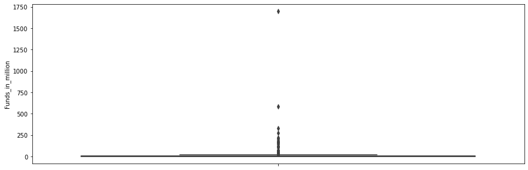

```python
fig, ax = plt.subplots(figsize=(15,5)) #Set Figure Size
sns.boxplot(data=df3, y='Funds_in_million');
```

### D.) Check the number of outliers greater than the upper fence.

```python
Q1 = df3['Funds_in_million'].quantile(0.25) #Calculate Q1
Q3 = df3['Funds_in_million'].quantile(0.75) #Calculate Q3
IQR = Q3 - Q1 #Calculate IQR (inter-quartile range)
print("The IQR of attribute Funds_in_million is:",IQR)
print('The number of outliers greater than the upper fence is:',(df3['Funds_in_million'] > (Q3 + 1.5 * IQR)).sum())
```

```
The IQR of attribute Funds_in_million is: 8.72975
The number of outliers greater than the upper fence is: 60
```

### E.) Check frequency of the OperatingState features classes.

```python
df3['OperatingState'].value_counts() #Frequency table of the OperatingState features classes
```

```
Operating    319
Acquired      66
Closed        57
Ipo            4
Name: OperatingState, dtype: int64
```

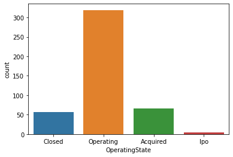

```python
sns.countplot(x='OperatingState', data=df3) #Frequency plot of the OperatingState features classes
```

## 4.) Statistical Analysis:

### A.) Is there any significant difference between Funds raised by companies that are still operating vs companies that closed down?

```python
df3.groupby(['OperatingState']).sum()
```

| OperatingState | Funds_in_million |
| --- | --- |
| Acquired | 872.0510 |
| Closed | 185.7157 |
| Ipo | 551.1000 |
| Operating | 6080.8372 |

From the above table, it is observed that there is a numerical difference between Funds raised by companies that are still operating vs companies that closed down!

### C.) Test for significance and conclusion

This is an example of a two sample test. The two samples belong to the OperatingState category of Operating vs Closed. These two categories form two independent groups.

A two sample t-test has to be performed to test for significance

```python
group1 = df3['OperatingState']=='Operating' #Array of rows where OperatingState is 'Operating'
group1 = df3[group1]['Funds_in_million'] #Array of funds where OperatingState is 'Operating'
group2 = df3['OperatingState']=='Closed' #Array of row where OperatingState is 'Closed'
group2 = df3[group2]['Funds_in_million'] #Array of funds where OperatingState is 'Closed'
# two-sample t-test
from scipy.stats import ttest_ind
t_statistic, p_value = ttest_ind(group1, group2)
print(t_statistic, p_value)
# p_value < 0.05 => alternative hypothesis:
# they don't have the same mean at the 5% significance level
print ("two-sample t-test p-value=", p_value)
```

```
1.1382924515740138 0.25572701885629406
two-sample t-test p-value= 0.25572701885629406
```

**Conclusion:**

As p-value > 0.05, null hypothesis (H0) cannot be rejected.

### D.) Make a copy of the original data frame.

```python
df2.head() #Original data frame
```

|  | Startup | Product | Funding | Event | Result | OperatingState |
| --- | --- | --- | --- | --- | --- | --- |
| 0 | 2600Hz | 2600hz.com | NaN | Disrupt SF 2013 | Contestant | Operating |
| 1 | 3DLT | 3dlt.com | $630K | Disrupt NYC 2013 | Contestant | Closed |
| 2 | 3DPrinterOS | 3dprinteros.com | NaN | Disrupt SF 2016 | Contestant | Operating |
| 3 | 3Dprintler | 3dprintler.com | $1M | Disrupt NY 2016 | Audience choice | Operating |
| 4 | 42 Technologies | 42technologies.com | NaN | Disrupt NYC 2013 | Contestant | Operating |

### E.) Check frequency distribution of Result variables.

```python
df2['Result'].value_counts() #Frequency table of the Result attribute
```

```
Contestant         488
Finalist            84
Audience choice     41
Winner              26
Runner up           23
Name: Result, dtype: int64
```

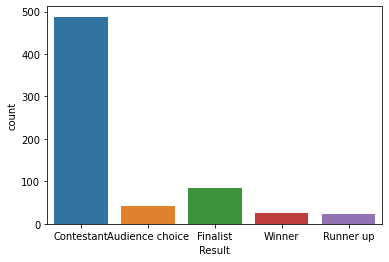

```python
sns.countplot(x='Result', data=df2) #Frequency plot of the Result variables
```

### F.) Calculate percentage of winners that are still operating and percentage of contestants that are still operating

```python
pd.crosstab(df2['OperatingState'],df2['Result'])
```

| Result OperatingState | Audience choice | Contestant | Finalist | Runner up | Winner |
| --- | --- | --- | --- | --- | --- |
| Acquired | 0 | 62 | 15 | 2 | 7 |
| Closed | 9 | 90 | 7 | 0 | 0 |
| Ipo | 0 | 4 | 1 | 0 | 0 |
| Operating | 32 | 332 | 61 | 21 | 19 |

```python
#Percentage of winners that are still operating
winners = 26
winner_opr = 19
print('Percentage of winners that are still operating:',round((winner_opr/winners)*100,2))
```

```
Percentage of winners that are still operating: 73.08
```

```python
#Percentage of contestants that are still operating
contestant = 488
contestant_opr = 332
print('Percentage of contestants that are still operating:',round((contestant_opr/contestant)*100,2))
```

```
Percentage of contestants that are still operating: 68.03
```

### G.) Write your hypothesis comparing the proportion of companies that are operating between winners and contestants:

Percentage of winners that are still operating: 73.08 %

Percentage of contestants that are still operating: 68.03 %

The proportions are different but are they statistically significant?

**Null Hypothesis (H0)** = The proportion of companies that are operating between winners and contestants are equal

**Alternative Hypothesis (Ha)** = The proportion of companies that are operating between winners and contestants are **NOT** equal.

### H.) Test for significance and conclusion

Test of Proportions has to be conducted in this case.

```python
from statsmodels.stats.proportion import proportions_ztest

stat, pval = proportions_ztest([winner_opr, contestant_opr] , [winners, contestant])

if pval < 0.05:
    print(f'With a p-value of {round(pval,4)} the difference is significant. aka |We reject the null|')
else:
    print(f'With a p-value of {round(pval,4)} the difference is not significant. aka |We fail to reject the null|')
```

```
With a p-value of 0.5902 the difference is not significant. aka |We fail to reject the null|
```

**Conclusion** We fail to reject the null hypothesis (H0)!

### I.) Select only the Event that has ‘disrupt’ keyword from 2013 onwards.

```python
df2 = df2[df2['Event'].str.contains('Disrupt')] # Filtering the rows where Event has disrupt keyword
df2['EventYear'] = df2['Event'].str[-4:] #Extract Year from Event attribute and create new Year column
df2
```

|  | Startup | Product | Funding | Event | Result | OperatingState | EventYear |
| --- | --- | --- | --- | --- | --- | --- | --- |
| 0 | 2600Hz | 2600hz.com | NaN | Disrupt SF 2013 | Contestant | Operating | 2013 |
| 1 | 3DLT | 3dlt.com | $630K | Disrupt NYC 2013 | Contestant | Closed | 2013 |
| 2 | 3DPrinterOS | 3dprinteros.com | NaN | Disrupt SF 2016 | Contestant | Operating | 2016 |
| 3 | 3Dprintler | 3dprintler.com | $1M | Disrupt NY 2016 | Audience choice | Operating | 2016 |
| 4 | 42 Technologies | 42technologies.com | NaN | Disrupt NYC 2013 | Contestant | Operating | 2013 |
| ... | ... | ... | ... | ... | ... | ... | ... |
| 653 | ZAP! | zapreklam.com/ | NaN | Disrupt EU 2014 | Audience choice | Operating | 2014 |
| 654 | ZEFR | zefr.com | $62.1M | Disrupt NYC 2010 | Contestant | Operating | 2010 |
| 656 | Zenefits | zenefits.com | $583.6M | Disrupt NYC 2013 | Finalist | Operating | 2013 |
| 660 | Zula | zulaapp.com | $3.4M | Disrupt SF 2013 | Audience choice | Operating | 2013 |
| 661 | Zumper | zumper.com | $31.5M | Disrupt SF 2012 | Finalist | Operating | 2012 |

465 rows × 7 columns

```python
df2['EventYear'] = df2['EventYear'].apply(pd.to_numeric)#Convert data type of EventYear column to numeric
year_filter=df2['EventYear']>=2013 #Create year filter from 2013 onwards
year_filter
```

```
0       True
1       True
2       True
3       True
4       True
       ...
653     True
654    False
656     True
660     True
661    False
Name: EventYear, Length: 465, dtype: bool
```

```python
year_filter = df2[year_filter]['Event'] #Pass year filter to extract events
year_filter #Only the Event that has ‘disrupt’ keyword from 2013 onwards
```

```
0          Disrupt SF 2013
1         Disrupt NYC 2013
2          Disrupt SF 2016
3          Disrupt NY 2016
4         Disrupt NYC 2013
              ...
646    Disrupt London 2015
648    Disrupt London 2015
653        Disrupt EU 2014
656       Disrupt NYC 2013
660        Disrupt SF 2013
Name: Event, Length: 276, dtype: object
```